# Isolation-by-distance

Jayna Bergman

2025-03-10

Version of R used: 4.3.3

## Project

Western toad DUs Genomics.

## Overview

### **Goal(s):**

The first section includes all individuals (after removing multiple from each site). Second section removes the “southern” group individuals, and the third color codes for the “southern” group.

### **Details about files and pipeline:**

vcf file: HO_0.5_AB_0.25-0.75_mac3_imiss33_SNP95_LD.recode.vcf

## Setting up the R environment

### Working directory:

```r
setwd("C:/Users/jayna/OneDrive/Desktop/School/Lee_Yaw_Lab/Masters_Thesis/Data_chapter/RMD")
```

### Libraries:

```r
# load libraries
library(dplyr)
library(knitr)
library(ggplot2)
library(tidyverse)
library(tidyr)
library(vcfR)
library(adegenet)
library(poppr)
library(hierfstat)
library(ape)
library(ade4)
library(dartR)
library(geosphere)
```

## **Step 1 of analysis:** VCF File

### Load and explore the data

Load the vcf file and it will be converted into a genlight object:

```r
vcf <- gl.read.vcf("./filtered_vcf/HO_0.5_AB_0.25-0.75_mac3_imiss33_SNP95_LD.recode.vcf")
```

[output not shown]

Look at the summary of the genlight object:

```r
vcf
```

```
##  /// GENLIGHT OBJECT /////////
##
##  // 40 genotypes,  11,950 binary SNPs, size: 2.5 Mb
##  20379 (4.26 %) missing data
##
##  // Basic content
##    @gen: list of 40 SNPbin
##    @ploidy: ploidy of each individual  (range: 2-2)
##
##  // Optional content
##    @ind.names:  40 individual labels
##    @loc.names:  11950 locus labels
##    @loc.all:  11950 alleles
##    @chromosome: factor storing chromosomes of the SNPs
##    @position: integer storing positions of the SNPs
##    @pop: population of each individual (group size range: 40-40)
##    @other: a list containing: loc.metrics  loc.metrics.flags  verbose  history  ind.metrics
```

Add meta data to the genlight object:

```r
## Clean individual names (remove excess text)
samples <- indNames(vcf)
new_names <- sub(".WETO_ref.sort*", "", samples)

indNames(vcf) <- new_names
indNames(vcf)
```

```
##  [1] "BO-27A-DNA80"     "FF-28-DNA80"      "HU2-DNA60"        "KA-5-DNA80"
##  [5] "LOST2-DNA60"      "ML4-DNA80"        "MM-02-DNA80"      "RA-03-DNA80"
##  [9] "RA-05-DNA80"      "RO2-DNA80"        "SI-3-DNA80"       "SU2-DNA80"
## [13] "WB-5-DNA80"       "WETO20-003-DNA80" "WETO22-022-DNA1"  "WETO22-022-DNA80"
## [17] "WETO22-053-DNA80" "WETO22-065-DNA80" "WETO22-074-DNA80" "WETO22-105-DNA80"
## [21] "WETO22-127-DNA80" "WETO22-158-DNA80" "WETO22-166-DNA80" "WETO22-177-DNA80"
## [25] "WETO23-011-DNA80" "WETO23-039-DNA80" "WETO23-058-DNA80" "WETO23-060-DNA80"
## [29] "WETO23-061-DNA80" "WETO23-062-DNA80" "WETO23-065-DNA80" "WETO23-077-DNA80"
## [33] "WETO23-089-DNA80" "WETO23-102-DNA80" "WETO23-118-DNA80" "WETO23-130-DNA80"
## [37] "WETO23-156-DNA80" "WETO23-191-DNA80" "WETO23-200-DNA80" "WETO23-226-DNA80"
```

```r
## Drop individuals to get one per site
gl_filtered <- gl.drop.ind(vcf, ind.list=c("RA-05-DNA80","WETO22-022-DNA80", "WETO23-065-DNA80", "WETO23-060-DNA80", "WETO23-061-DNA80", "WETO23-062-DNA80"))
```

```
## Starting gl.drop.ind
##   Processing genlight object with SNP data
##   Deleting specified individuals
##   Warning: Resultant dataset may contain monomorphic loci
##   Locus metrics not recalculated
## Completed: gl.drop.ind
```

```r
indNames(gl_filtered)
```

```
##  [1] "BO-27A-DNA80"     "FF-28-DNA80"      "HU2-DNA60"        "KA-5-DNA80"
##  [5] "LOST2-DNA60"      "ML4-DNA80"        "MM-02-DNA80"      "RA-03-DNA80"
##  [9] "RO2-DNA80"        "SI-3-DNA80"       "SU2-DNA80"        "WB-5-DNA80"
## [13] "WETO20-003-DNA80" "WETO22-022-DNA1"  "WETO22-053-DNA80" "WETO22-065-DNA80"
## [17] "WETO22-074-DNA80" "WETO22-105-DNA80" "WETO22-127-DNA80" "WETO22-158-DNA80"
## [21] "WETO22-166-DNA80" "WETO22-177-DNA80" "WETO23-011-DNA80" "WETO23-039-DNA80"
## [25] "WETO23-058-DNA80" "WETO23-077-DNA80" "WETO23-089-DNA80" "WETO23-102-DNA80"
## [29] "WETO23-118-DNA80" "WETO23-130-DNA80" "WETO23-156-DNA80" "WETO23-191-DNA80"
## [33] "WETO23-200-DNA80" "WETO23-226-DNA80"
```

```r
## Read in population data and add it to the genlight object
pops <- read.csv("C:/Users/jayna/OneDrive/Desktop/School/Lee_Yaw_Lab/Masters_Thesis/Data_chapter/plate2_individuals.csv")

## reorder samples in alphabetical order so downstream analyses match
pops <- pops[order(pops$Sample), ]


## Distinct to ensure one individual per population
pops_subset <- pops %>%
  subset(pops$imiss20_SNP96=="yes") %>%
  distinct(Long_dd, Lat_dd, .keep_all = TRUE)

## For the gl object
coords <- pops_subset %>%
  select(c("Lat_dd","Long_dd")) %>%
  rename(lat = "Lat_dd", lon ="Long_dd")


## For geographic distance maxtrix
coords2 <- pops_subset %>%
  select(c("Long_dd", "Lat_dd")) %>%
  rename(lon = "Long_dd", lat = "Lat_dd")

## Add coordinates to the gl object
gl_filtered@other$latlon <- coords

## setting populations to individual samples
## Allows pairwise comparisons between individuals for IBD
pop(gl_filtered) <- pops_subset$Sample
pop(gl_filtered)
```

```
##  [1] BO-27A       FF-28        HU2          KA-5         Lost-2
##  [6] ML4 H        MM-02        RA-03        RO2          SI-3
## [11] SU2          WB-5         WETO20-003   WETO22-022-1 WETO22-053
## [16] WETO22-065   WETO22-074   WETO22-105   WETO22-127   WETO22-158
## [21] WETO22-166   WETO22-177   WETO23-011   WETO23-039   WETO23-058
## [26] WETO23-077   WETO23-089   WETO23-102   WETO23-118   WETO23-130
## [31] WETO23-156   WETO23-191   WETO23-200   WETO23-226
## 34 Levels: BO-27A FF-28 HU2 KA-5 Lost-2 ML4 H MM-02 RA-03 RO2 SI-3 SU2 ... WETO23-226
```

Generate genetic distance matrix and geographic distance matrix to run a mantel test to determine IBD using all individuals

```r
## Genetic distance
#dist <- gl.dist.pop(gl_filtered, plot.out=TRUE, method = "nei")
#dist <- as.matrix(dist)

## Genlight obj to genind object (in order to calculated proportion of shared alleles)
gi_filtered <- gl2gi(gl_filtered)
```

```
## Starting gl2gi
##   Processing genlight object with SNP data
## Matrix converted.. Prepare genind object...
## Completed: gl2gi
```

```
## Analysis performed using provided genetic and Euclidean distance matrices. If a genlight object is provided, it is ignored.
```

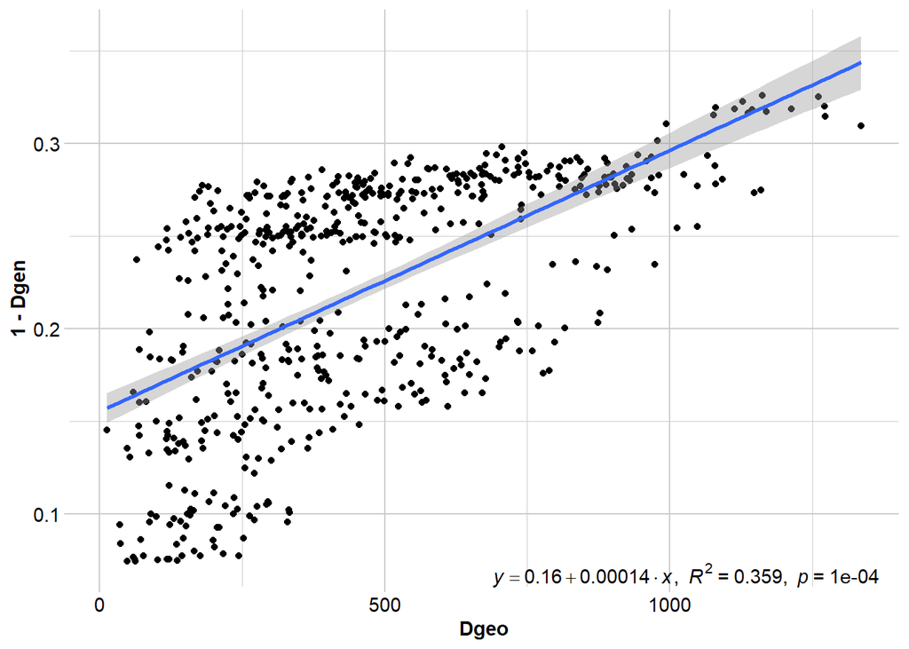

```
##   Coordinates used from: Dgeo provided.
##   Transformation of Dgeo: Dgeo
##   Genetic distance: Dgen provided
##   Tranformation of Dgen:  1 - Dgen
##
## Mantel statistic based on Pearson's product-moment correlation
##
## Call:
## vegan::mantel(xdis = Dgen, ydis = Dgeo, permutations = permutations,      na.rm = TRUE)
##
## Mantel statistic r: 0.5991
##       Significance: 1e-04
##
## Upper quantiles of permutations (null model):
##    90%    95%  97.5%    99%
## 0.0729 0.0958 0.1202 0.1470
## Permutation: free
## Number of permutations: 9999
##
##
## Completed: gl.ibd
```

```r
## Genetic distance matrix using the proportion of shared alleles
dist <- propShared(gi_filtered)


## Geographic distance matrix
geogDist <- distm(coords2)

## Convert distances to km (from m)
geogDist <- geogDist / 1000

## Add back column/row names to geog distance matrix
rownames(geogDist) <- pops_subset$Sample
colnames(geogDist) <- pops_subset$Sample



## calculate IBD using a mantel test. Need the transformation on the genetic distance because we need it to be 1 - proportion shared alleles for the Mantel test to calculate properly.
ibd <- gl.ibd(Dgen=dist, Dgeo=geogDist, Dgen_trans = '1 - Dgen', permutations = 9999)
```

IBD for the Calling population:

```r
## set the populations to calling and non-calling
pop(gl_filtered) <- pops_subset$Genetic_clade
pop(gl_filtered)
```

```
##  [1] Non-calling Non-calling Non-calling Non-calling Non-calling Non-calling
##  [7] Non-calling Non-calling Non-calling Non-calling Non-calling Non-calling
## [13] Non-calling Non-calling Calling     Calling     Calling     Calling
## [19] Calling     Calling     Calling     Calling     Calling     Calling
## [25] Calling     Non-calling Non-calling Non-calling Non-calling Non-calling
## [31] Calling     Non-calling Non-calling Non-calling
## Levels: Calling Non-calling
```

```r
## Filter for calling individuals
calling_gl <- gl.keep.pop(gl_filtered, "Calling")
```

```
## Starting gl.keep.pop
##   Processing genlight object with SNP data
##   Checking for presence of nominated populations
##   Retaining only populations Calling
##   Warning: Resultant dataset may contain monomorphic loci
##   Locus metrics not recalculated
## Completed: gl.keep.pop
```

```r
## change back to individual names
pop(calling_gl) <- indNames(calling_gl)
pop(calling_gl)
```

```
##  [1] WETO22-053-DNA80 WETO22-065-DNA80 WETO22-074-DNA80 WETO22-105-DNA80
##  [5] WETO22-127-DNA80 WETO22-158-DNA80 WETO22-166-DNA80 WETO22-177-DNA80
##  [9] WETO23-011-DNA80 WETO23-039-DNA80 WETO23-058-DNA80 WETO23-156-DNA80
## 12 Levels: WETO22-053-DNA80 WETO22-065-DNA80 ... WETO23-156-DNA80
```

```r
## Genetic distance
#dist_calling <- gl.dist.pop(calling_gl, plot.out=TRUE, method = "nei")
#dist_calling <- as.matrix(dist_calling)

## Convert to a gen ind oject
calling_gi <- gl2gi(calling_gl)
```

```
## Starting gl2gi
##   Processing genlight object with SNP data
## Matrix converted.. Prepare genind object...
## Completed: gl2gi
```

```
## Analysis performed using provided genetic and Euclidean distance matrices. If a genlight object is provided, it is ignored.
```

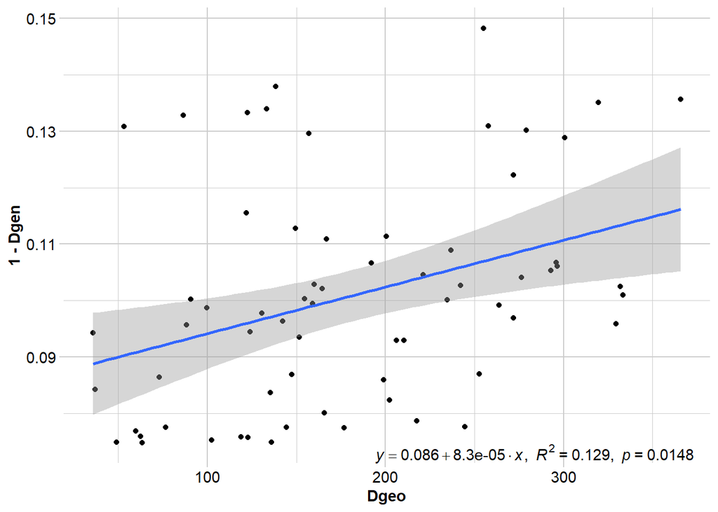

```
##   Coordinates used from: Dgeo provided.
##   Transformation of Dgeo: Dgeo
##   Genetic distance: Dgen provided
##   Tranformation of Dgen:  1 - Dgen
##
## Mantel statistic based on Pearson's product-moment correlation
##
## Call:
## vegan::mantel(xdis = Dgen, ydis = Dgeo, permutations = permutations,      na.rm = TRUE)
##
## Mantel statistic r: 0.3585
##       Significance: 0.0148
##
## Upper quantiles of permutations (null model):
##   90%   95% 97.5%   99%
## 0.223 0.284 0.326 0.378
## Permutation: free
## Number of permutations: 9999
##
##
## Completed: gl.ibd
```

```r
## genetic distance using proportion of shared alleles
dist_calling <- propShared(calling_gi)

dist_calling <- as.dist(dist_calling)


## Geographic distance - subset the population data
coords_calling <- pops_subset %>%
  subset(Genetic_clade == "Calling") %>%
    select(c("Long_dd", "Lat_dd")) %>%
  rename(lon = "Long_dd", lat = "Lat_dd")

geogDist_calling <- distm(coords_calling)

## Genetic distance from m to km
geogDist_calling <- geogDist_calling / 1000

geogDist_calling <- as.dist(geogDist_calling)


## IBD
ibd_calling <- gl.ibd(Dgen=dist_calling, Dgeo=geogDist_calling, Dgen_trans = '1 - Dgen', permutations = 9999)
```

IBD for the Non-calling population:

```r
## filter for the Non-calling pop
noncalling_gl <- gl.keep.pop(gl_filtered, "Non-calling")
```

```
## Starting gl.keep.pop
##   Processing genlight object with SNP data
##   Checking for presence of nominated populations
##   Retaining only populations Non-calling
##   Warning: Resultant dataset may contain monomorphic loci
##   Locus metrics not recalculated
## Completed: gl.keep.pop
```

```r
pop(noncalling_gl) <- indNames(noncalling_gl)
pop(noncalling_gl)
```

```
##  [1] BO-27A-DNA80     FF-28-DNA80      HU2-DNA60        KA-5-DNA80
##  [5] LOST2-DNA60      ML4-DNA80        MM-02-DNA80      RA-03-DNA80
##  [9] RO2-DNA80        SI-3-DNA80       SU2-DNA80        WB-5-DNA80
## [13] WETO20-003-DNA80 WETO22-022-DNA1  WETO23-077-DNA80 WETO23-089-DNA80
## [17] WETO23-102-DNA80 WETO23-118-DNA80 WETO23-130-DNA80 WETO23-191-DNA80
## [21] WETO23-200-DNA80 WETO23-226-DNA80
## 22 Levels: BO-27A-DNA80 FF-28-DNA80 HU2-DNA60 KA-5-DNA80 ... WETO23-226-DNA80
```

```r
## Genetic distance
#dist_noncalling <- gl.dist.pop(noncalling_gl, plot.out=TRUE, method = "nei")
#dist_noncalling <- as.matrix(dist_noncalling)

## Convert to a gen ind oject
noncalling_gi <- gl2gi(noncalling_gl)
```

```
## Starting gl2gi
##   Processing genlight object with SNP data
## Matrix converted.. Prepare genind object...
## Completed: gl2gi
```

```
## Analysis performed using provided genetic and Euclidean distance matrices. If a genlight object is provided, it is ignored.
```

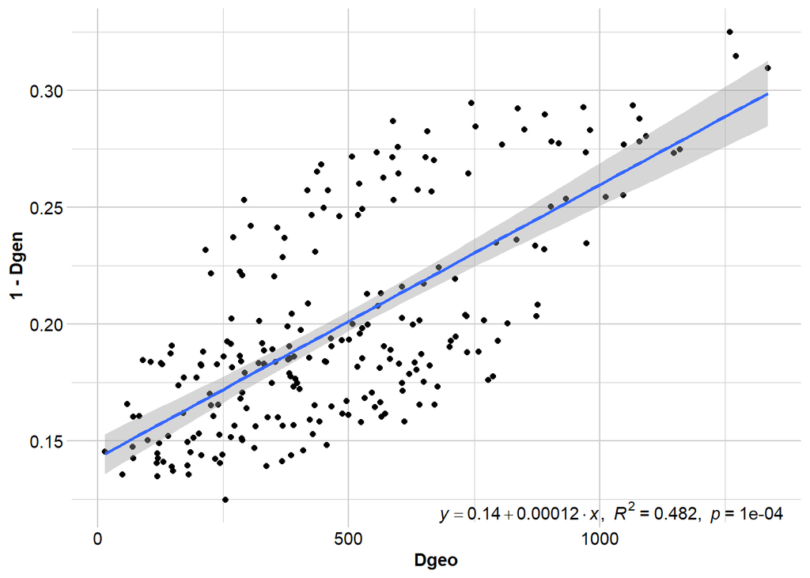

```
##   Coordinates used from: Dgeo provided.
##   Transformation of Dgeo: Dgeo
##   Genetic distance: Dgen provided
##   Tranformation of Dgen:  1 - Dgen
##
## Mantel statistic based on Pearson's product-moment correlation
##
## Call:
## vegan::mantel(xdis = Dgen, ydis = Dgeo, permutations = permutations,      na.rm = TRUE)
##
## Mantel statistic r: 0.6944
##       Significance: 1e-04
##
## Upper quantiles of permutations (null model):
##   90%   95% 97.5%   99%
## 0.158 0.208 0.252 0.299
## Permutation: free
## Number of permutations: 9999
##
##
## Completed: gl.ibd
```

```r
## genetic distance using proportion of shared alleles
dist_noncalling <- propShared(noncalling_gi)


## Geographic distance
coords_noncalling <- pops_subset %>%
  subset(Genetic_clade == "Non-calling") %>%
    select(c("Long_dd", "Lat_dd")) %>%
  rename(lon = "Long_dd", lat = "Lat_dd")

geogDist_noncalling <- distm(coords_noncalling)

## Convert geographic distance from m to km
geogDist_noncalling <- geogDist_noncalling / 1000


## IBD
ibd_noncalling <- gl.ibd(Dgen=dist_noncalling, Dgeo=geogDist_noncalling, Dgen_trans = '1 - Dgen', permutations = 9999)
```

Generate dataframe for plot using all individuals:

```r
## Generate long format dataframe for genetic distances
dist_df <- as.data.frame(dist)
rownames(dist_df) <- pops_subset$Sample
colnames(dist_df) <- pops_subset$Sample

dist_long <- dist_df %>%
  rownames_to_column(var = "Individual_1") %>%
  pivot_longer(cols = -Individual_1,
               names_to = "Individual_2",
               values_to = "Gen_dist")


## Generate long format dataframe for geographic distances
geogDist_df <- as.data.frame(geogDist)


geogdist_long <- geogDist_df %>%
  rownames_to_column(var = "Individual_1") %>%
  pivot_longer(cols = -Individual_1,
               names_to = "Individual_2",
               values_to = "Geog_dist")

All_ind_df <- cbind(dist_long, geogdist_long$Geog_dist)

All_ind_df <- All_ind_df %>%
  rename("Geog_dist" = "geogdist_long$Geog_dist")



## subset to sample and genetic clade
genetic_clades <- pops_subset %>%
  select(Sample, Genetic_clade)


## add columns for individual 1 and 2
All_ind_df <- All_ind_df %>%
  left_join(genetic_clades, by=c("Individual_1" = "Sample")) %>%
  rename("Ind1_gen_clade" = Genetic_clade) %>%
  left_join(genetic_clades, by=c("Individual_2" = "Sample")) %>%
  rename("Ind2_gen_clade" = Genetic_clade)


## Add Type of comparison column (depending on genetic clade of ind 1 and ind 2)
All_ind_df <- All_ind_df %>%
  mutate(Type = case_when(
    Ind1_gen_clade == "Calling" & Ind2_gen_clade == "Calling" ~ "Calling vs Calling",
    Ind1_gen_clade == "Non-calling" & Ind2_gen_clade == "Non-calling" ~ "Non-calling vs Non-calling",
    TRUE ~ "Calling vs Non-calling"
  ))


## Remove zeros (i.e. comparisons of the same site)
All_ind_data <- All_ind_df[!(All_ind_df$Geog_dist==0.0 &
                               All_ind_df$Gen_dist == 1.00000000), ]

write.csv(All_ind_data, "C:/Users/jayna/OneDrive/Desktop/School/Lee_Yaw_Lab/Masters_Thesis/Data_chapter/RMD/IBD/Proportion_shared_alleles/All_ind_IBD_matrix_PropSA.csv", row.names=FALSE)
All_ind_data <- read.csv("C:/Users/jayna/OneDrive/Desktop/School/Lee_Yaw_Lab/Masters_Thesis/Data_chapter/RMD/IBD/Proportion_shared_alleles/All_ind_IBD_matrix_PropSA.csv")
```

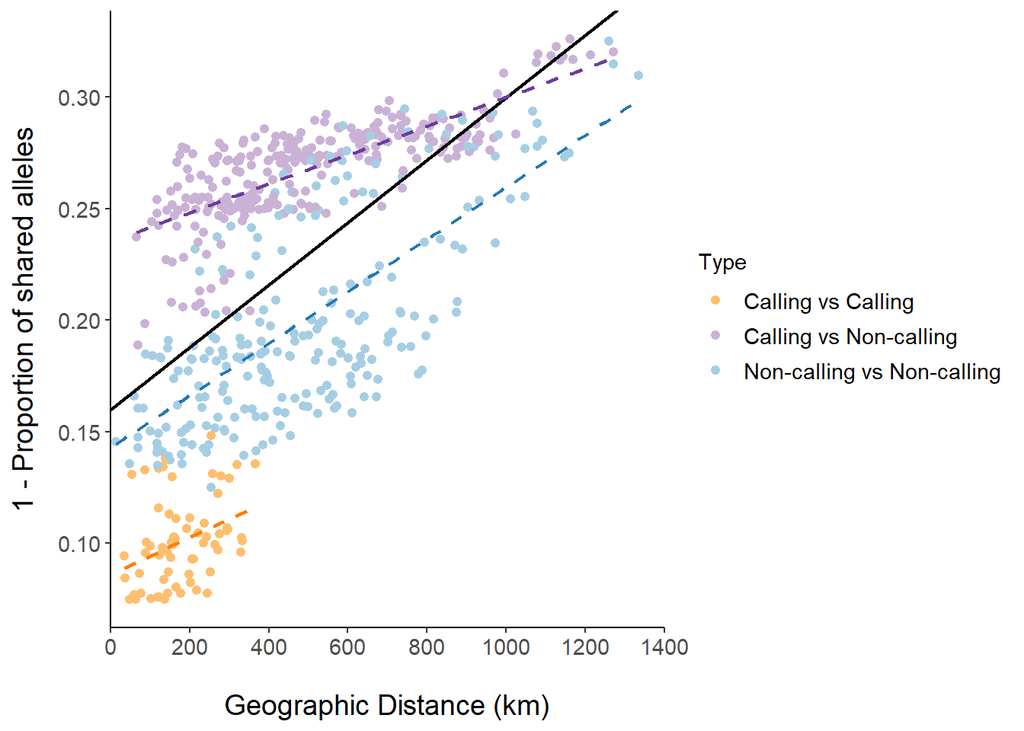

```r
## plot
ibd_plot <- ggplot(All_ind_data, aes(x=Geog_dist, y=1 - Gen_dist, color = Type)) +
  geom_point(size=1.8) +
  scale_x_continuous(expand=c(0,0), limits=c(0, 1400), breaks=seq(0, 1400, by= 200)) +
  scale_color_manual(values = c("Calling vs Non-calling"= "#CAB2D6", "Calling vs Calling" = "#FDBF6F", "Non-calling vs Non-calling"= "#A6CEE3")) +
  geom_abline(slope=0.00014, intercept=0.16, color = "black", lwd=0.75) +
  #geom_abline(slope=0.00043, intercept = 0.057, color = "#FF7F00", lwd=0.75) +
  #geom_abline(slope =7.2e-05, intercept=0.15, color = "#1F78B4", lwd=0.75) +
  geom_smooth(data = All_ind_data[All_ind_data$Type == "Calling vs Non-calling", ], method = "lm", se = FALSE, color = "#6A3D9A", lwd=0.75,
              linetype="dashed") +
  geom_smooth(data = All_ind_data[All_ind_data$Type == "Calling vs Calling", ], method = "lm", se = FALSE, color = "#FF7F00", lwd=0.75,
              linetype="dashed") +
  geom_smooth(data = All_ind_data[All_ind_data$Type == "Non-calling vs Non-calling", ], method = "lm", se = FALSE, color = "#1F78B4", lwd=0.75,
              linetype="dashed") +
  theme(legend.text = element_text(size = 11),
        axis.line = element_line(color="black"),
        panel.background=element_rect(fill="white", color=NA),
        axis.text.x = element_text(size=11),
        axis.text.y = element_text(size= 11),
        axis.title.x = element_text(margin=margin(t=17), size = 14),
        axis.title.y = element_text (margin=margin(r=10), size=14)) +
  labs(x="Geographic Distance (km)",
       y="1 - Proportion of shared alleles")

ibd_plot
```

```r
ggsave(plot=ibd_plot, "C:/Users/jayna/OneDrive/Desktop/School/Lee_Yaw_Lab/Masters_Thesis/Data_chapter/RMD/IBD/Proportion_shared_alleles/IBD_all_individuals_imiss33_SNP95.jpeg", dpi=800, width=8, height=8)
```

### Without “Southern cluster”

```r
## Remove individuals that correspond to the southern group
gl_filtered_wo_WLNP <- gl.drop.ind(gl_filtered, ind.list=c("WETO20-003-DNA80", "WETO23-077-DNA80", "WETO23-089-DNA80"))
```

```
## Starting gl.drop.ind
##   Processing genlight object with SNP data
##   Deleting specified individuals
##   Warning: Resultant dataset may contain monomorphic loci
##   Locus metrics not recalculated
## Completed: gl.drop.ind
```

```r
## Remove individuals from pops dataframe
pops_subset_wo_WLNP <- pops_subset %>%
  filter(!(Sample=="WETO20-003" | Sample=="WETO23-077" | Sample=="WETO23-089"))


## separate coords for geographic distance matrix
coords_wo_WLNP <- pops_subset_wo_WLNP %>%
  select(c("Long_dd", "Lat_dd")) %>%
  rename(lon = "Long_dd", lat = "Lat_dd")


## setting populations to individual samples
## Allows pairwise comparisons between individuals for IBD
pop(gl_filtered_wo_WLNP) <- pops_subset_wo_WLNP$Sample
pop(gl_filtered_wo_WLNP)
```

```
##  [1] BO-27A       FF-28        HU2          KA-5         Lost-2
##  [6] ML4 H        MM-02        RA-03        RO2          SI-3
## [11] SU2          WB-5         WETO22-022-1 WETO22-053   WETO22-065
## [16] WETO22-074   WETO22-105   WETO22-127   WETO22-158   WETO22-166
## [21] WETO22-177   WETO23-011   WETO23-039   WETO23-058   WETO23-102
## [26] WETO23-118   WETO23-130   WETO23-156   WETO23-191   WETO23-200
## [31] WETO23-226
## 31 Levels: BO-27A FF-28 HU2 KA-5 Lost-2 ML4 H MM-02 RA-03 RO2 SI-3 SU2 ... WETO23-226
```

Generate genetic distance matrix and geographic distance matrix to run a mantel test to determine IBD using all individuals

```r
## Genetic distance
#dist_wo_WLNP <- gl.dist.pop(gl_filtered_wo_WLNP, plot.out=TRUE, method = "nei")
#dist_wo_WLNP <- as.matrix(dist_wo_WLNP)

## Convert to a gen ind oject
gi_filtered_wo_WLNP <- gl2gi(gl_filtered_wo_WLNP)
```

```
## Starting gl2gi
##   Processing genlight object with SNP data
## Matrix converted.. Prepare genind object...
## Completed: gl2gi
```

```
## Analysis performed using provided genetic and Euclidean distance matrices. If a genlight object is provided, it is ignored.
```

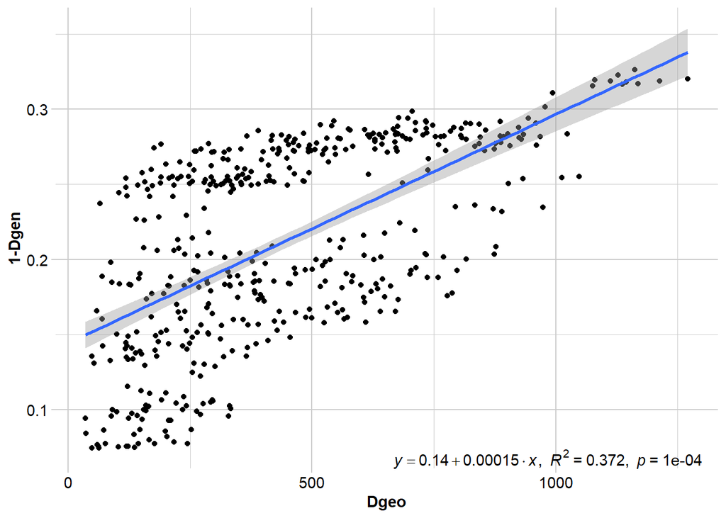

```
##   Coordinates used from: Dgeo provided.
##   Transformation of Dgeo: Dgeo
##   Genetic distance: Dgen provided
##   Tranformation of Dgen:  1-Dgen
##
## Mantel statistic based on Pearson's product-moment correlation
##
## Call:
## vegan::mantel(xdis = Dgen, ydis = Dgeo, permutations = permutations,      na.rm = TRUE)
##
## Mantel statistic r: 0.6099
##       Significance: 1e-04
##
## Upper quantiles of permutations (null model):
##    90%    95%  97.5%    99%
## 0.0643 0.0887 0.1101 0.1412
## Permutation: free
## Number of permutations: 9999
##
##
## Completed: gl.ibd
```

```r
## genetic distance using proportion of shared alleles
dist_wo_WLNP <- propShared(gi_filtered_wo_WLNP)


## Geographic distance
geogDist_wo_WLNP <- distm(coords_wo_WLNP)
geogDist_wo_WLNP <- geogDist_wo_WLNP / 1000

## Add back column/row names
rownames(geogDist_wo_WLNP) <- pops_subset_wo_WLNP$Sample
colnames(geogDist_wo_WLNP) <- pops_subset_wo_WLNP$Sample

## Run IBD analysis
ibd_wo_WLNP <- gl.ibd(Dgen=dist_wo_WLNP, Dgeo=geogDist_wo_WLNP, Dgen_trans = '1-Dgen', permutations = 9999)
```

IBD for the Calling population (without WLNP):

```r
## Calling pop
pop(gl_filtered_wo_WLNP) <- pops_subset_wo_WLNP$Genetic_clade
pop(gl_filtered_wo_WLNP)
```

```
##  [1] Non-calling Non-calling Non-calling Non-calling Non-calling Non-calling
##  [7] Non-calling Non-calling Non-calling Non-calling Non-calling Non-calling
## [13] Non-calling Calling     Calling     Calling     Calling     Calling
## [19] Calling     Calling     Calling     Calling     Calling     Calling
## [25] Non-calling Non-calling Non-calling Calling     Non-calling Non-calling
## [31] Non-calling
## Levels: Calling Non-calling
```

```r
calling_gl_wo_WLNP <- gl.keep.pop(gl_filtered_wo_WLNP, "Calling")
```

```
## Starting gl.keep.pop
##   Processing genlight object with SNP data
##   Checking for presence of nominated populations
##   Retaining only populations Calling
##   Warning: Resultant dataset may contain monomorphic loci
##   Locus metrics not recalculated
## Completed: gl.keep.pop
```

```r
pop(calling_gl_wo_WLNP) <- indNames(calling_gl_wo_WLNP)
pop(calling_gl_wo_WLNP)
```

```
##  [1] WETO22-053-DNA80 WETO22-065-DNA80 WETO22-074-DNA80 WETO22-105-DNA80
##  [5] WETO22-127-DNA80 WETO22-158-DNA80 WETO22-166-DNA80 WETO22-177-DNA80
##  [9] WETO23-011-DNA80 WETO23-039-DNA80 WETO23-058-DNA80 WETO23-156-DNA80
## 12 Levels: WETO22-053-DNA80 WETO22-065-DNA80 ... WETO23-156-DNA80
```

```r
## Genetic distance
#dist_calling_wo_WLNP <- gl.dist.pop(calling_gl_wo_WLNP, plot.out=TRUE, method = "nei")
#dist_calling_wo_WLNP <- as.matrix(dist_calling_wo_WLNP)

## Convert to a gen ind oject
calling_gi_wo_WLNP <- gl2gi(calling_gl_wo_WLNP)
```

```
## Starting gl2gi
##   Processing genlight object with SNP data
## Matrix converted.. Prepare genind object...
## Completed: gl2gi
```

```
## Analysis performed using provided genetic and Euclidean distance matrices. If a genlight object is provided, it is ignored.
```

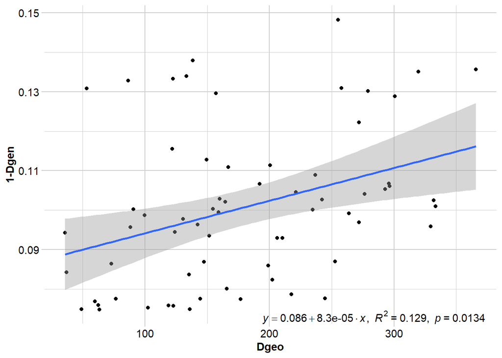

```
##   Coordinates used from: Dgeo provided.
##   Transformation of Dgeo: Dgeo
##   Genetic distance: Dgen provided
##   Tranformation of Dgen:  1-Dgen
##
## Mantel statistic based on Pearson's product-moment correlation
##
## Call:
## vegan::mantel(xdis = Dgen, ydis = Dgeo, permutations = permutations,      na.rm = TRUE)
##
## Mantel statistic r: 0.3585
##       Significance: 0.0134
##
## Upper quantiles of permutations (null model):
##   90%   95% 97.5%   99%
## 0.225 0.280 0.324 0.369
## Permutation: free
## Number of permutations: 9999
##
##
## Completed: gl.ibd
```

```r
## genetic distance using proportion of shared alleles
dist_calling_wo_WLNP <- propShared(calling_gi_wo_WLNP)


## Geographic distance
coords_calling_wo_WLNP <- pops_subset_wo_WLNP %>%
  subset(Genetic_clade == "Calling") %>%
    select(c("Long_dd", "Lat_dd")) %>%
  rename(lon = "Long_dd", lat = "Lat_dd")

geogDist_calling_wo_WLNP <- distm(coords_calling_wo_WLNP)

geogDist_calling_wo_WLNP <- geogDist_calling_wo_WLNP / 1000

## IBD
ibd_calling_wo_WLNP <- gl.ibd(Dgen=dist_calling_wo_WLNP, Dgeo=geogDist_calling_wo_WLNP, Dgen_trans = '1-Dgen', permutations = 9999)
```

Generate dataframe for plot using all individuals (without WLNP):

```r
## Generate long format dataframe for genetic distances
dist_df_wo_WLNP <- as.data.frame(dist_wo_WLNP)
rownames(dist_df_wo_WLNP) <- pops_subset_wo_WLNP$Sample
colnames(dist_df_wo_WLNP) <- pops_subset_wo_WLNP$Sample


dist_df_wo_WLNP_lower <- dist_df_wo_WLNP
dist_df_wo_WLNP_lower[!lower.tri(as.matrix(dist_df_wo_WLNP))] <- NA


dist_long_wo_WLNP <- dist_df_wo_WLNP_lower %>%
  rownames_to_column(var = "Individual_1") %>%
  pivot_longer(cols = -Individual_1,
               names_to = "Individual_2",
               values_to = "Gen_dist")

dist_long_wo_WLNP <- na.omit(dist_long_wo_WLNP)


## Generate long format dataframe for geographic distances
geogDist_df_wo_WLNP <- as.data.frame(geogDist_wo_WLNP)

geogDist_df_wo_WLNP_lower <- geogDist_df_wo_WLNP
geogDist_df_wo_WLNP_lower[!lower.tri(as.matrix(geogDist_df_wo_WLNP))] <- NA

geogdist_long_wo_WLNP <- geogDist_df_wo_WLNP_lower %>%
  rownames_to_column(var = "Individual_1") %>%
  pivot_longer(cols = -Individual_1,
               names_to = "Individual_2",
               values_to = "Geog_dist")

geogdist_long_wo_WLNP <- na.omit(geogdist_long_wo_WLNP)


All_ind_df_wo_WLNP <- cbind(dist_long_wo_WLNP, geogdist_long_wo_WLNP$Geog_dist)


All_ind_df_wo_WLNP <- All_ind_df_wo_WLNP %>%
  rename("Geog_dist" = "geogdist_long_wo_WLNP$Geog_dist")


## Add calling and non-calling labels to
genetic_clades_wo_WLNP <- pops_subset_wo_WLNP %>%
  select(Sample, Genetic_clade)

All_ind_df_wo_WLNP <- All_ind_df_wo_WLNP %>%
  left_join(genetic_clades_wo_WLNP, by=c("Individual_1" = "Sample")) %>%
  rename("Ind1_gen_clade" = Genetic_clade) %>%
  left_join(genetic_clades_wo_WLNP, by=c("Individual_2" = "Sample")) %>%
  rename("Ind2_gen_clade" = Genetic_clade)


## Add Type column
All_ind_df_wo_WLNP <- All_ind_df_wo_WLNP %>%
  mutate(Type = case_when(
    Ind1_gen_clade == "Calling" & Ind2_gen_clade == "Calling" ~ "Calling vs Calling",
    Ind1_gen_clade == "Non-calling" & Ind2_gen_clade == "Non-calling" ~ "Non-calling vs Non-calling",
    TRUE ~ "Calling vs Non-calling"
  ))



write.csv(All_ind_df_wo_WLNP, "C:/Users/jayna/OneDrive/Desktop/School/Lee_Yaw_Lab/Masters_Thesis/Data_chapter/RMD/IBD/Proportion_shared_alleles/All_ind_IBD_matrix_wo_WLNP_PropSA.csv", row.names=FALSE)
All_ind_df_wo_WLNP <- read.csv("C:/Users/jayna/OneDrive/Desktop/School/Lee_Yaw_Lab/Masters_Thesis/Data_chapter/RMD/IBD/Proportion_shared_alleles/All_ind_IBD_matrix_wo_WLNP_PropSA.csv")
```

Make a new plot:

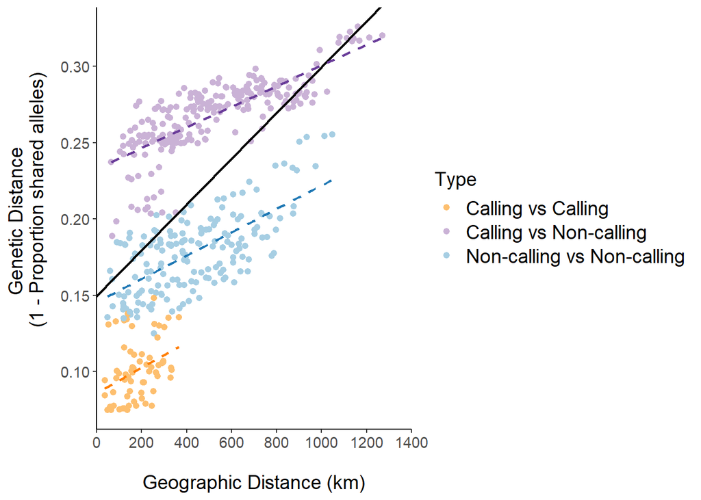

```r
## plot
ibd_plot_wo_WLNP <- ggplot(All_ind_df_wo_WLNP, aes(x=Geog_dist, y=1 - Gen_dist, color = Type)) +
  geom_point(size=1.8) +
  scale_x_continuous(expand=c(0,0), limits=c(0, 1400), breaks=seq(0, 1400, by= 200)) +
  scale_color_manual(values = c("Calling vs Non-calling"= "#CAB2D6", "Calling vs Calling" = "#FDBF6F", "Non-calling vs Non-calling"= "#A6CEE3")) +

  geom_abline(slope=0.00015, intercept=0.15, color = "black", lwd=0.75) +

  #geom_abline(slope=8.3e-05, intercept = 0.086, color = "#FF7F00", lwd=0.75, linetype="dashed") +
  #geom_abline(slope =7.7e-05, intercept=0.15, color = "#1F78B4", lwd=0.75, linetype="dashed") +

  geom_smooth(data = All_ind_df_wo_WLNP[All_ind_df_wo_WLNP$Type == "Calling vs Non-calling", ], method = "lm", se = FALSE, color = "#6A3D9A", lwd=0.75, linetype = "dashed") +
  geom_smooth(data = All_ind_df_wo_WLNP[All_ind_df_wo_WLNP$Type == "Calling vs Calling", ], method = "lm", se = FALSE, color = "#FF7F00", lwd=0.75, linetype = "dashed") +
  geom_smooth(data = All_ind_df_wo_WLNP[All_ind_df_wo_WLNP$Type == "Non-calling vs Non-calling", ], method = "lm", se = FALSE, color = "#1F78B4", lwd=0.75, linetype = "dashed") +

  theme(legend.text = element_text(size = 14),
        legend.title = element_text(size = 14),
        axis.line = element_line(color="black"),
        panel.background=element_rect(fill="white", color=NA),
        axis.text.x = element_text(size=11),
        axis.text.y = element_text(size= 11),
        axis.title.x = element_text(margin=margin(t=17), size = 14),
        axis.title.y = element_text (margin=margin(r=10), size=14)) +
  labs(x="Geographic Distance (km)",
       y="Genetic Distance
       (1 - Proportion shared alleles)")

ibd_plot_wo_WLNP
```

```r
ggsave(plot=ibd_plot_wo_WLNP, "C:/Users/jayna/OneDrive/Desktop/School/Lee_Yaw_Lab/Masters_Thesis/Data_chapter/RMD/IBD/Proportion_shared_alleles/IBD_all_individuals_wo_WLNP.jpeg", dpi=800, width=8, height=8)
```

### With “Southern cluster” colored separate

Run IBD for the “Southern cluster”

```r
pop(gl_filtered) <- pops_subset$Three_clusters

## Southern population
southern_gl <- gl.keep.pop(gl_filtered, "CotC")
```

```
## Starting gl.keep.pop
##   Processing genlight object with SNP data
##   Checking for presence of nominated populations
##   Retaining only populations CotC
##   Warning: Resultant dataset may contain monomorphic loci
##   Locus metrics not recalculated
## Completed: gl.keep.pop
```

```r
pop(southern_gl) <- indNames(southern_gl)
pop(southern_gl)
```

```
## [1] WETO20-003-DNA80 WETO23-077-DNA80 WETO23-089-DNA80
## Levels: WETO20-003-DNA80 WETO23-077-DNA80 WETO23-089-DNA80
```

```r
## Genetic distance
#dist_southern <- gl.dist.pop(southern_gl, plot.out=TRUE, method = "nei")
#dist_southern <- as.matrix(dist_southern)

## Convert to a gen ind oject
southern_gi <- gl2gi(southern_gl)
```

```
## Starting gl2gi
##   Processing genlight object with SNP data
## Matrix converted.. Prepare genind object...
## Completed: gl2gi
```

```
## Analysis performed using provided genetic and Euclidean distance matrices. If a genlight object is provided, it is ignored.
```

```
## 'nperm' >= set of all permutations: complete enumeration.
```

```
## Set of permutations < 'minperm'. Generating entire set.
```

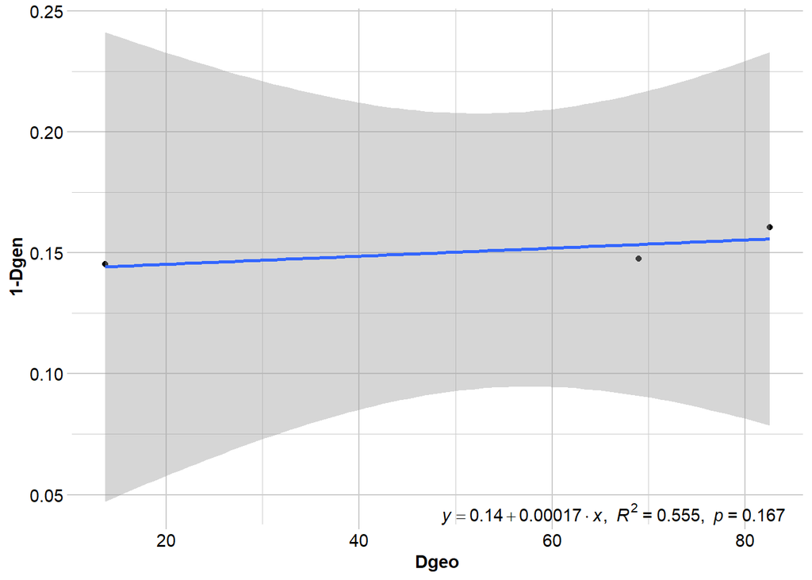

```
##   Coordinates used from: Dgeo provided.
##   Transformation of Dgeo: Dgeo
##   Genetic distance: Dgen provided
##   Tranformation of Dgen:  1-Dgen
##
## Mantel statistic based on Pearson's product-moment correlation
##
## Call:
## vegan::mantel(xdis = Dgen, ydis = Dgeo, permutations = permutations,      na.rm = TRUE)
##
## Mantel statistic r: 0.745
##       Significance: 0.16667
##
## Upper quantiles of permutations (null model):
##   90%   95% 97.5%   99%
## 0.509 0.529 0.539 0.545
## Permutation: free
## Number of permutations: 5
##
##
## Completed: gl.ibd
```

```r
## genetic distance using proportion of shared alleles
dist_southern <- propShared(southern_gi)


## Geographic distance
coords_southern <- pops_subset %>%
  subset(Three_clusters == "CotC") %>%
    select(c("Long_dd", "Lat_dd")) %>%
  rename(lon = "Long_dd", lat = "Lat_dd")

geogDist_southern <- distm(coords_southern)

geogDist_southern <- geogDist_southern / 1000


## IBD
ibd_southern <- gl.ibd(Dgen=dist_southern, Dgeo=geogDist_southern, Dgen_trans = '1-Dgen', permutations = 9999)
```

Generate dataframe for plot using all individuals (labeling the southern cluster):

```r
## Generate long format dataframe for genetic distances
dist_df_three_clusters <- as.data.frame(dist)
rownames(dist_df_three_clusters) <- pops_subset$Sample
colnames(dist_df_three_clusters) <- pops_subset$Sample

dist_long_three_clusters <- dist_df_three_clusters %>%
  rownames_to_column(var = "Individual_1") %>%
  pivot_longer(cols = -Individual_1,
               names_to = "Individual_2",
               values_to = "Gen_dist")


## Generate long format dataframe for geographic distances
geogDist_df_three_clusters <- as.data.frame(geogDist)


geogdist_long_three_clusters <- geogDist_df_three_clusters %>%
  rownames_to_column(var = "Individual_1") %>%
  pivot_longer(cols = -Individual_1,
               names_to = "Individual_2",
               values_to = "Geog_dist")

All_ind_df_three_clusters <- cbind(dist_long_three_clusters, geogdist_long_three_clusters$Geog_dist)

rm(geogdist_long_three_clusters)

All_ind_df_three_clusters <- All_ind_df_three_clusters %>%
  rename("Geog_dist" = "geogdist_long_three_clusters$Geog_dist")



## Add calling and non-calling labels to
genetic_clades_three_clusters <- pops_subset %>%
  select(Sample, Three_clusters)

All_ind_df_three_clusters <- All_ind_df_three_clusters %>%
  left_join(genetic_clades_three_clusters, by=c("Individual_1" = "Sample")) %>%
  rename("Ind1_gen_clade" = Three_clusters) %>%
  left_join(genetic_clades_three_clusters, by=c("Individual_2" = "Sample")) %>%
  rename("Ind2_gen_clade" = Three_clusters)


## Add Type column
All_ind_df_three_clusters <- All_ind_df_three_clusters %>%
  mutate(Type = case_when(
    Ind1_gen_clade == "Calling" & Ind2_gen_clade == "Calling" ~ "Calling vs Calling",
    Ind1_gen_clade == "Non-calling" & Ind2_gen_clade == "Non-calling" ~ "Non-calling vs Non-calling",
    Ind1_gen_clade == "CotC" & Ind2_gen_clade == "Non-calling" ~ "Non-calling vs CotC",
    Ind1_gen_clade == "Non-calling" & Ind2_gen_clade == "CotC" ~ "Non-calling vs CotC",
    Ind1_gen_clade == "CotC" & Ind2_gen_clade == "Calling" ~ "Calling vs CotC",
    Ind1_gen_clade == "Calling" & Ind2_gen_clade == "CotC" ~ "Calling vs CotC",
    Ind1_gen_clade == "CotC" & Ind2_gen_clade == "CotC" ~ "CotC vs CotC",
    TRUE ~ "Calling vs Non-calling"
  ))


## Remove zeros (i.e. comparisons of the same site)
All_ind_data_three_clusters <- All_ind_df_three_clusters[!(All_ind_df_three_clusters$Geog_dist==0.0 &
                               All_ind_df_three_clusters$Gen_dist == 1.00000000), ]

write.csv(All_ind_data_three_clusters, "C:/Users/jayna/OneDrive/Desktop/School/Lee_Yaw_Lab/Masters_Thesis/Data_chapter/RMD/IBD/Proportion_shared_alleles/All_ind_IBD_matrix_Southern_cluster_labelled.csv", row.names=FALSE)
All_ind_data_three_clusters <- read.csv("C:/Users/jayna/OneDrive/Desktop/School/Lee_Yaw_Lab/Masters_Thesis/Data_chapter/RMD/IBD/Proportion_shared_alleles/All_ind_IBD_matrix_Southern_cluster_labelled.csv")
```

Make a new plot:

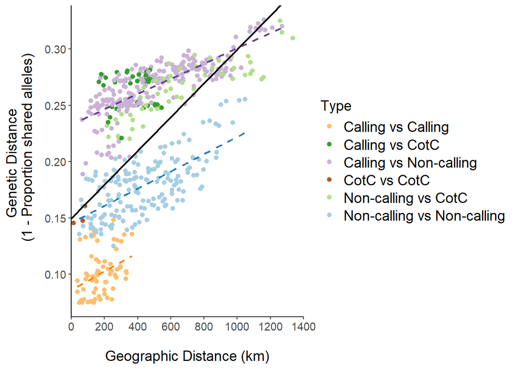

```r
## plot
ibd_plot_three_clusters <- ggplot(All_ind_data_three_clusters, aes(x=Geog_dist, y=1 - Gen_dist, color = Type)) +
  geom_point(size=1.8) +
  scale_x_continuous(expand=c(0,0), limits=c(0, 1400), breaks=seq(0, 1400, by= 200)) +

  scale_color_manual(values = c("Calling vs Non-calling"= "#CAB2D6", "Calling vs Calling" = "#FDBF6F", "Non-calling vs Non-calling"= "#A6CEE3", "Calling vs CotC" = "#33A02C", "Non-calling vs CotC" = "#B2DF8A", "CotC vs CotC" = "#B15928")) +

  geom_abline(slope=0.00015, intercept=0.15, color = "black", lwd=0.75) +
  geom_smooth(data = All_ind_df_wo_WLNP[All_ind_df_wo_WLNP$Type == "Calling vs Non-calling", ], method = "lm", se = FALSE, color = "#6A3D9A", lwd=0.75, linetype="dashed") +
  geom_smooth(data = All_ind_df_wo_WLNP[All_ind_df_wo_WLNP$Type == "Calling vs Calling", ], method = "lm", se = FALSE, color = "#FF7F00", lwd=0.75, linetype="dashed") +
  geom_smooth(data = All_ind_df_wo_WLNP[All_ind_df_wo_WLNP$Type == "Non-calling vs Non-calling", ], method = "lm", se = FALSE, color = "#1F78B4", lwd=0.75, linetype="dashed") +

   theme(legend.text = element_text(size = 14),
        legend.title = element_text(size = 14),
        axis.line = element_line(color="black"),
        panel.background=element_rect(fill="white", color=NA),
        axis.text.x = element_text(size=11),
        axis.text.y = element_text(size= 11),
        axis.title.x = element_text(margin=margin(t=17), size = 14),
        axis.title.y = element_text (margin=margin(r=10), size=14)) +
  labs(x="Geographic Distance (km)",
       y="Genetic Distance
       (1 - Proportion shared alleles)")


ibd_plot_three_clusters
```

```r
ggsave(plot=ibd_plot_three_clusters, "C:/Users/jayna/OneDrive/Desktop/School/Lee_Yaw_Lab/Masters_Thesis/Data_chapter/RMD/IBD/Proportion_shared_alleles/IBD_all_individuals_Three_clusters_imiss33_SNP95.jpeg", dpi=800, width=8, height=8)
```

### Conclusions

Three separate plots are made: 1) All points, 2) Removing the third genetic cluster, 3) color coding the third genetic cluster.

### Specific notes for the manuscript/thesis

Plot 2 and 3 will go into the main manuscript.